# Supervised Machine Learning Models - GLM and Deep Learning

## Understanding the data

The data set available to us consists of 80,000 rows of loan default data. The variable can be bucketed into types such as:

- Applicant data: Age, education, os_type and so on
- Credit data: credit checks, credict card limit, debit card score and so on.
- Call data: calls made, service calls, high risk calls and so on.
- Loan data: loan term, loan amount, and so on.

We go through the following steps to clean the data:

1. Rename columns into more understandble and typical terms
2. Removing unnecessary, repititve columns
3. Fixing data types by converting categorical data from int64 to categoricals
4. Creating new features for missing data, missing phone activity and mismatch between application location and IP location
5. Changing system-based error values like -1, NAs, 99, 999 to 0
6. Binning continuous variables like loan term, loan amount, age, years of active phone usage.
7. Cleaning up category variables to include top levels and binning others in other.

We added two additional feature engineering steps this week:

1. Split application date to day of the week, week of the year, and month of the year.
2. Use K-means clustering add a feature to the dataset

```python
import pandas as pd
import numpy as np
import seaborn as sns
import matplotlib.pyplot as plt
import re

%matplotlib inline
```

```python
data = pd.read_csv('loan_default.csv')
```

```python
#renaming columns to more readable ones
oldnames = data.columns.tolist()
newnames = ["X", "unnamed", "id", "loan_default", "age_yr", "gender", "education", "loan_term", "date_applied", "OS_type", "app_city_level",
               "ip_appl_mismatch", "ap009", "cq_p2p_7d", "cq_sl_7d", "cq_p2p_1m", "cq_sl_1m", "cq_p2p_3m", "cq_sl_3m", "cq_p2p_6m", "cq_sl_6m", "cq_bank_6m",
               "count_hit_r6", "count_hit_r7", "count_hit_r8", "td025", "td026", "td027", "td028", "td029", "td044", "td048", "td051",
                "td054", "td055", "td061", "td062", "cq_time_1m", "cq_time_2m", "t_loan_amount", "cc_flag_8", "cc_mob_max_m", "dc_amount_score",
               "dc_utility_score", "dc_limit_score", "days_app_fhr", "days_app_fcc", "avg_len_chr_call", "avg_len_chr_call_in",
               "avg_len_chr_call_out", "avg_len_c_call","total_in_call_1m", "total_out_call_3m", "family_in_call_3m", "family_out_call_3m",
               "count_col_call_3m", "count_abnormal_call_2m", "count_abnormal_in_call_2m", "count_abnormal_call_3m", "count_abnormal_in_call_3m", "count_abnormal_out_call_3m",
               "count_abcall_day_2m", "count_abcall_day_3m", "distinct_call_1m", "distinct_out_call_1m", "distinct_call_2m", "distinct_out_call_2m", "distinct_call_3m", "distinct_out_call_3m",
               "freqout_in_call_2m", "freqin_out_call_2m", "freqout_out_call_2m", "freqin_in_call_2m", "freqout_in_call_3m", "freqin_out_call_3m", "freqout_out_call_3m", "len_freqout_out_call_3m", "len_freqin_in_call_3m",
               "count_service_out_call_2m", "count_service_call_3m", "count_service_out_call_3m", "len_service_call_1m", "len_service_out_call_1m", "len_service_call_2m", "len_service_out_call_2m",
               "len_service_call_3m", "len_service_out_call_3m", "years_phone_active", "mob_brand"]

data.rename(columns = {oldnames[i] : newnames[i] for i in range(len(oldnames))}, errors = 'raise', inplace = True)

#removing date and additional id columns
a = list(range(2,89))
#a.remove(8)
data = data.iloc[:, a]
data.head()

#creating new dataset with fixed types
data1 = data.copy()
#data1.info()
```

```python
def data_clean(data1):
    #Fixing the following datatypes to factors
    data1['loan_default'] = data1['loan_default'].astype('object')
    data1['date_applied'] = pd.to_datetime(data1['date_applied'])
    data1['day_applied'] = data1['date_applied'].dt.dayofweek
    data1['week_applied'] = data1['date_applied'].dt.weekofyear
    data1['month_applied'] = data1['date_applied'].dt.month
    data1['gender'] = data1['gender'].astype(str)
    data1['loan_term'] = data1['loan_term'].astype(str)
    data1['education'] = data1['education'].astype(str)
    data1['OS_type'] = data1['OS_type'].astype(str)
    data1['app_city_level'] = data1['app_city_level'].astype(str)
    data1['ip_appl_mismatch'] = data1['ip_appl_mismatch'].astype(str)
    data1['ap009'] = data1['ap009'].astype(str)
    data1['mob_brand'] = data1['mob_brand'].astype(str)
    #creating a new variable mismatch to see if there is a mismatch between the level of the ip address and the application city
    data1['mismatch'] = np.where(data1['app_city_level'] == data1['ip_appl_mismatch'], 1, 0)
    #dropping columns which do not add any value based on earlier EDA
    drop_cols = ["td044", "td048", "td051", "td054", "td055", "td061", "td062", 'date_applied']
    data1.drop(drop_cols, axis = 1, inplace = True)
    #replacing categories in mobile brands
    data1['mob_brand'] = data1['mob_brand'].str.replace("IPHONE\\d", 'Iphone') #cleaning up iphone levels
    data1['mob_brand'] = data1['mob_brand'].str.replace("IPAD\\d", 'Iphone') #cleaning up iphone levels
    data1['mob_brand'] = data1['mob_brand'].str.lower() #converting all brands to lower
    #other_brands = pd.Series(["web", "iphone", "oppo", "noinfo", "vivo", "huawei", "samsung", "xiaomi", "honor", "meizu",
    #            "gionee", "leeco", "letv", "360", "coolpad"]) #creating top 15 brands
    #data1['mob_brand'] = data1['mob_brand'].apply(lambda x: x if any([k == x for k in other_brands]) else 'other') #rebucketing all other brands
    #creating a new variable phone missing for missing active phone yeards data
    data1['phone_missing'] = data1['years_phone_active'].apply(lambda x: 1 if np.isnan(x) else 0)
    #creating new variables for rows with missing data
    data1['nodata_1'] = data1['total_in_call_1m'].apply(lambda x: 1 if np.isnan(x) else 0)
    data1['nodata_2'] = data1['count_hit_r6'].apply(lambda x: 1 if np.isnan(x) else 0)
    check_cols = data1.isin([-98, -99, -1]).sum().sort_values(ascending = False)
    check_cols = check_cols[check_cols > 0]
    check_cols = check_cols.index
    for col in check_cols:
        try:
            check_rows = data[data[col].isin([-99, -98, -1])].index
            data1.iloc[check_rows, col] = np.nan
        except:
            continue
    #Creating index of columns with null values
    null_col = data1.isnull().sum().sort_values(ascending = False)
    null_col = null_col[ null_col > 0]
    #Looping through to replace NAs with mean values
    null_col = null_col.index
    for col in null_col:
        data1.loc[:, col].fillna(0, inplace = True)
    return data1

def train_binning(data1):
    #binning age, phone usage and loan term data and creating bins for use in next function
    data1['age_yr_bin'], year_bin = pd.qcut(data1['age_yr'], q = 10, precision = 0, retbins= True)
    year_bin = np.concatenate(([-np.inf], year_bin[1:-1], [np.inf]))
    data1['t_loan_amount_bin'], loan_bin = pd.qcut(data1['t_loan_amount'], q = 5, precision = 0, retbins = True)
    loan_bin = np.concatenate(([-np.inf], loan_bin[1:-1], [np.inf]))
    data1['distinct_call_3m_bins'], dc3m_bin = pd.qcut(data1['distinct_call_3m'], q = 5, precision = 0, retbins = True)
    dc3m_bin = np.concatenate(([-np.inf], dc3m_bin[1:-1], [np.inf]))
    data1['years_phone_active_bins'], phone_bin = pd.qcut(data1['years_phone_active'], q = 5, precision = 0, retbins = True)
    phone_bin = np.concatenate(([-np.inf], phone_bin[1:-1], [np.inf]))
    data1['total_in_call_1m_bins'], tic1_bin = pd.qcut(data1['total_in_call_1m'], q = 5, precision = 0, retbins = True)
    tic1_bin = np.concatenate(([-np.inf], tic1_bin[1:-1], [np.inf]))
    data1['len_service_out_call_1m_bins'], lsoc1_bin = pd.qcut(data1['len_service_out_call_1m'], q = 5, precision = 0, retbins = True)
    lsoc1_bin = np.concatenate(([-np.inf], lsoc1_bin[1:-1], [np.inf]))
    data1['cq_sl_7d_bins'], cqls7_bin = pd.qcut(data1['cq_sl_7d'], q = 5, duplicates = 'drop', precision = 0, retbins = True)
    cqls7_bin = np.concatenate(([-np.inf], cqls7_bin[1:-1], [np.inf]))
    data1['len_service_out_call_2m_bins'], lsoc2_bin = pd.qcut(data1['len_service_out_call_2m'], q = 5, precision = 0, retbins = True)
    lsoc2_bin = np.concatenate(([-np.inf], lsoc2_bin[1:-1], [np.inf]))
    #data1.drop(['age_yr', 't_loan_amount', 'years_phone_active', "cq_sl_1m", 'cq_p2p_1m', 'count_hit_r6', "cq_p2p_3m", "cq_sl_3m", "cq_p2p_6m", "cq_sl_6m", "cq_bank_6m", "cq_time_2m", "count_abnormal_call_3m",
     #           "dc_utility_score", "dc_limit_score", "days_app_fcc", "avg_len_chr_call", "avg_len_chr_call_in", "count_abnormal_in_call_3m", "count_abnormal_out_call_3m",
      #          "count_abcall_day_2m", "count_abcall_day_3m", "freqin_out_call_3m", "freqout_out_call_3m", "distinct_call_1m", "distinct_out_call_1m", "distinct_call_2m",
       #         "distinct_call_3m", 'len_service_out_call_1m', 'total_in_call_1m', 'cq_sl_7d', 'len_service_out_call_2m', 'avg_len_c_call', 'total_out_call_3m', 'family_in_call_3m',
        #        'family_out_call_3m', 'count_col_call_3m', 'freqout_in_call_2m', 'freqout_out_call_2m', 'freqin_out_call_2m', 'len_service_call_2m', 'len_service_out_call_3m',
         #       "len_freqout_out_call_3m", "len_freqin_in_call_3m", "count_service_out_call_2m", "count_service_call_3m", "count_service_out_call_3m", 'nodata_2',
          #      'count_abnormal_call_2m', 'distinct_out_call_2m', 'freqout_in_call_3m',
           #     "len_service_call_1m"], axis = 1, inplace = True) #remove high correlation variables
    return data1, year_bin, loan_bin, phone_bin, dc3m_bin, tic1_bin, lsoc1_bin, cqls7_bin, lsoc2_bin

def test_binning(data1, year_bin, loan_bin, phone_bin, dc3m_bin, tic1_bin, lsoc1_bin, cqls7_bin, lsoc2_bin):
    data1['age_yr_bin'] = pd.cut(data1['age_yr'], year_bin)
    data1['t_loan_amount_bin'] = pd.cut(data1['t_loan_amount'], loan_bin)
    data1['years_phone_active_bins'] = pd.cut(data1['years_phone_active'], phone_bin)
    data1['distinct_call_3m_bins'] = pd.cut(data1['distinct_call_3m'], dc3m_bin)
    data1['total_in_call_1m_bins'] = pd.cut(data1['total_in_call_1m'], tic1_bin)
    data1['len_service_out_call_1m_bins'] = pd.cut(data1['len_service_out_call_1m'], lsoc1_bin)
    data1['cq_sl_7d_bins'] = pd.cut(data1['cq_sl_7d'], cqls7_bin)
    data1['len_service_out_call_2m_bins'] = pd.cut(data1['len_service_out_call_2m'], lsoc2_bin)
    #data1.drop(['age_yr', 't_loan_amount', 'years_phone_active', "cq_sl_1m", 'cq_p2p_1m', 'count_hit_r6', "cq_p2p_3m", "cq_sl_3m", "cq_p2p_6m", "cq_sl_6m", "cq_bank_6m", "cq_time_2m", "count_abnormal_call_3m",
     #           "dc_utility_score", "dc_limit_score", "days_app_fcc", "avg_len_chr_call", "avg_len_chr_call_in", "count_abnormal_in_call_3m", "count_abnormal_out_call_3m",
      #          "count_abcall_day_2m", "count_abcall_day_3m", "freqin_out_call_3m", "freqout_out_call_3m", "distinct_call_1m", "distinct_out_call_1m", "distinct_call_2m",
       #         "distinct_call_3m", 'len_service_out_call_1m', 'total_in_call_1m', 'cq_sl_7d', 'len_service_out_call_2m', 'avg_len_c_call', 'total_out_call_3m', 'family_in_call_3m',
        #        'family_out_call_3m', 'count_col_call_3m', 'freqout_in_call_2m', 'freqout_out_call_2m', 'freqin_out_call_2m', 'len_service_call_2m', 'len_service_out_call_3m',
         #      'count_abnormal_call_2m', 'distinct_out_call_2m', 'freqout_in_call_3m',
          #      "len_service_call_1m"], axis = 1, inplace = True)
    return data1

# 'cq_time_1m', 't_loan_amount_bin', 'count_abnormal_call_2m', 'family_in_call_3m', 'total_out_call_3m', 'count_hit_r7', 'freqout_in_call_3m', 'family_out_call_3m',
 #   'len_service_call_3m', 'count_abnormal_in_call_2m', 'len_service_out_call_3m', 'freqin_in_call_2m'
```

## Setting up train and test sets for modeling

We use scikit learns train_test_split function to create train and test datasets for modelling.

We also use the functions built in the previous section to clean the dataset and build and include only required features, and to build a list of the predictor columns and set the target to loan default.

```python
%%time

#Creating train and test datasets
from sklearn.model_selection import train_test_split

train, test = train_test_split(data1,test_size=0.2, random_state = 257)
```

```
Wall time: 699 ms
```

```python
%%time
%%capture [--no-stderr]

train = data_clean(train)
test = data_clean(test)
train, t_year_bin, t_loan_bin, t_phone_bin, t_dc3m_bin, t_tic1_bin, t_lsoc1_bin, t_cqls7_bin, t_lsoc2_bin = train_binning(train)
test = test_binning(test, t_year_bin, t_loan_bin, t_phone_bin, t_dc3m_bin, t_tic1_bin, t_lsoc1_bin, t_cqls7_bin, t_lsoc2_bin)
```

```
Wall time: 2.84 s
```

In addition, this week, we use kMeans clustering from the sci-kit learn package to build one additional feature. This clustering would provide additional information which could be useful to improve our predictions.

```
Wall time: 13.1 s
```

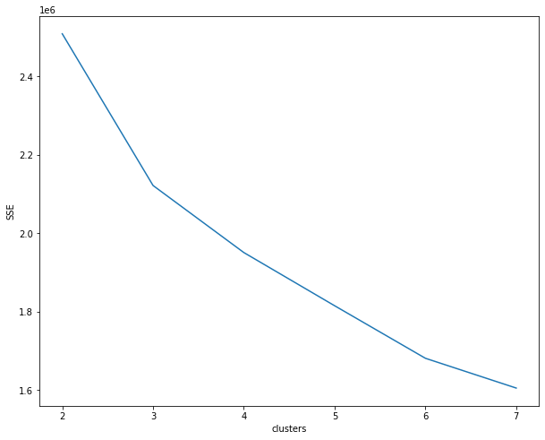

```python
%%time
data_num = train.select_dtypes(include = ['float', 'int'])
test_num = test.select_dtypes(include = ['float', 'int'])

from sklearn.cluster import KMeans
from sklearn.preprocessing import StandardScaler

scaler = StandardScaler()
cluster_data = scaler.fit_transform(data_num)
test_cluster = scaler.fit_transform(test_num)

#Identifying best set of clusters
sse = []
for n in range(2, 8):
    kmeans = KMeans(n_clusters = n, random_state= 250)
    kmeans.fit(cluster_data)
    sse.append(kmeans.inertia_)

model_sse = pd.DataFrame(data = { 'clusters' : range(2,8), 'SSE' : sse})

plt.figure(figsize= (10,8))
sns.lineplot(x = 'clusters', y = 'SSE', data = model_sse)
```

Basd on the elbow plot, we will use a 3 cluster solution.

```python
%%time
#building a 3-cluster model
kmeans = KMeans(n_clusters = 3, random_state = 250)
kmeans.fit(cluster_data)
```

```
Wall time: 1.88 s
```

```
KMeans(n_clusters=3, random_state=250)
```

```python
%%time
%%capture [--no-stderr]
train['cluster'] = kmeans.labels_
```

```
Wall time: 1.99 ms
```

```python
%%time
%%capture [--no-stderr]
test['cluster'] = kmeans.predict(test_cluster)
```

```
Wall time: 12.9 ms
```

```python
%%time
train, valid = train_test_split(train, test_size = 0.2, stratify = train['loan_default'], random_state = 257)
```

```
Wall time: 126 ms
```

```python
%%time
target = 'loan_default'
predictors = train.columns.tolist()
predictors.remove('loan_default')
predictors.remove('id')
```

```
Wall time: 0 ns
```

## Setting up the algorithm

We set up the algorithm through the following steps:

- Initiate h2o clusters
- create a function to identify important variables
- create a function to build a gains table
- create a function to plot AUC and precision curves

```python
import h2o
h2o.init(max_mem_size="5G")
```

[output not shown]

| H2O_cluster_uptime: | 03 secs |
| --- | --- |
| H2O_cluster_timezone: | America/New_York |
| H2O_data_parsing_timezone: | UTC |
| H2O_cluster_version: | 3.30.1.3 |
| H2O_cluster_version_age: | 1 month and 26 days |
| H2O_cluster_name: | H2O_from_python_karth_pn2tej |
| H2O_cluster_total_nodes: | 1 |
| H2O_cluster_free_memory: | 4.445 Gb |
| H2O_cluster_total_cores: | 8 |
| H2O_cluster_allowed_cores: | 8 |
| H2O_cluster_status: | accepting new members, healthy |
| H2O_connection_url: | http://127.0.0.1:54321 |
| H2O_connection_proxy: | {"http": null, "https": null, "no": "192.168.99.100"} |
| H2O_internal_security: | False |
| H2O_API_Extensions: | Amazon S3, Algos, AutoML, Core V3, TargetEncoder, Core V4 |
| Python_version: | 3.8.6 final |

```python
from h2o.estimators.glm import H2OGeneralizedLinearEstimator
import warnings
warnings.filterwarnings('ignore')
```

```python
def VarImp(model_name):

    from sklearn.metrics import roc_curve,auc
    from sklearn.metrics import average_precision_score
    from sklearn.metrics import precision_recall_curve
    import matplotlib.pyplot as plt

    # plot the variable importance
    plt.rcdefaults()
    variables = model_name._model_json['output']['variable_importances']['variable']
    y_pos = np.arange(len(variables))
    fig, ax = plt.subplots(figsize = (6,len(variables)/2))
    scaled_importance = model_name._model_json['output']['variable_importances']['scaled_importance']
    ax.barh(y_pos,scaled_importance,align='center',color='green')
    ax.set_yticks(y_pos)
    ax.set_yticklabels(variables)
    ax.invert_yaxis()
    ax.set_xlabel('Scaled Importance')
    ax.set_title('Variable Importance')
    plt.show()

def createGains(model, test_hex, target):
    predictions = model.predict(test_hex)['p1']
    test_scores = test_hex[target].cbind(predictions).as_data_frame()

    #sort on prediction (descending), add id, and decile for groups containing 1/10 of datapoints
    test_scores = test_scores.sort_values(by='p1',ascending=False)
    test_scores['row_id'] = range(0,0+len(test_scores))
    test_scores['decile'] = ( test_scores['row_id'] / (len(test_scores)/10) ).astype(int)
    #see count by decile
    test_scores.loc[test_scores['decile'] == 10]=9
    test_scores['decile'].value_counts()

    #create gains table
    gains = test_scores.groupby('decile')[target].agg(['count','sum'])
    gains.columns = ['count','actual']
    gains

    #add features to gains table
    gains['non_actual'] = gains['count'] - gains['actual']
    gains['cum_count'] = gains['count'].cumsum()
    gains['cum_actual'] = gains['actual'].cumsum()
    gains['cum_non_actual'] = gains['non_actual'].cumsum()
    gains['percent_cum_actual'] = (gains['cum_actual'] / np.max(gains['cum_actual'])).round(2)
    gains['percent_cum_non_actual'] = (gains['cum_non_actual'] / np.max(gains['cum_non_actual'])).round(2)
    gains['if_random'] = np.max(gains['cum_actual']) /10
    gains['if_random'] = gains['if_random'].cumsum()
    gains['lift'] = (gains['cum_actual'] / gains['if_random']).round(2)
    gains['K_S'] = np.abs( gains['percent_cum_actual'] -  gains['percent_cum_non_actual'] ) * 100
    gains['gain']=(gains['cum_actual']/gains['cum_count']*100).round(2)
    gains = pd.DataFrame(gains)
    return(gains)

def createGains_aml(model, test_hex, target):
    predictions = model.predict(test_hex)
    test_scores = test_hex[target].cbind(predictions).as_data_frame()

    #sort on prediction (descending), add id, and decile for groups containing 1/10 of datapoints
    test_scores = test_scores.sort_values(by='predict',ascending=False)
    test_scores['row_id'] = range(0,0+len(test_scores))
    test_scores['decile'] = ( test_scores['row_id'] / (len(test_scores)/10) ).astype(int)
    #see count by decile
    test_scores.loc[test_scores['decile'] == 10]=9
    test_scores['decile'].value_counts()

    #create gains table
    gains = test_scores.groupby('decile')[target].agg(['count','sum'])
    gains.columns = ['count','actual']
    gains

    #add features to gains table
    gains['non_actual'] = gains['count'] - gains['actual']
    gains['cum_count'] = gains['count'].cumsum()
    gains['cum_actual'] = gains['actual'].cumsum()
    gains['cum_non_actual'] = gains['non_actual'].cumsum()
    gains['percent_cum_actual'] = (gains['cum_actual'] / np.max(gains['cum_actual'])).round(2)
    gains['percent_cum_non_actual'] = (gains['cum_non_actual'] / np.max(gains['cum_non_actual'])).round(2)
    gains['if_random'] = np.max(gains['cum_actual']) /10
    gains['if_random'] = gains['if_random'].cumsum()
    gains['lift'] = (gains['cum_actual'] / gains['if_random']).round(2)
    gains['K_S'] = np.abs( gains['percent_cum_actual'] -  gains['percent_cum_non_actual'] ) * 100
    gains['gain']=(gains['cum_actual']/gains['cum_count']*100).round(2)
    gains = pd.DataFrame(gains)
    return(gains)

def ROC_AUC(my_result,df,target):
    from sklearn.metrics import roc_curve,auc
    from sklearn.metrics import average_precision_score
    from sklearn.metrics import precision_recall_curve
    import matplotlib.pyplot as plt

    # ROC
    y_actual = df[target].as_data_frame()
    y_pred = my_result.predict(df)['predict'].as_data_frame()
    fpr = list()
    tpr = list()
    roc_auc = list()
    fpr,tpr,_ = roc_curve(y_actual,y_pred)
    roc_auc = auc(fpr,tpr)

    # Precision-Recall
    average_precision = average_precision_score(y_actual,y_pred)

    print('')
    print('   * ROC curve: The ROC curve plots the true positive rate vs. the false rositive sate')
    print('')
    print('	  * The area under the curve (AUC): A value between 0.5 (random) and 1.0 (perfect), measuring the prediction accuracy')
    print('')
    print('   * Recall (R) = The number of true positives / (the number of true positives + the number of false negatives)')
    print('')

    # plotting
    plt.figure(figsize=(10,4))

    # ROC
    plt.subplot(1,2,1)
    plt.plot(fpr,tpr,color='darkorange',lw=2,label='ROC curve (area=%0.2f)' % roc_auc)
    plt.plot([0,1],[0,1],color='navy',lw=3,linestyle='--')
    plt.xlim([0.0,1.0])
    plt.ylim([0.0,1.05])
    plt.xlabel('False Positive Rate')
    plt.ylabel('True Positive Rate')
    plt.title('Receiver operating characteristic: AUC={0:0.4f}'.format(roc_auc))
    plt.legend(loc='lower right')

    # Precision-Recall
    plt.subplot(1,2,2)
    precision,recall,_ = precision_recall_curve(y_actual,y_pred)
    plt.step(recall,precision,color='b',alpha=0.2,where='post')
    plt.fill_between(recall,precision,step='post',alpha=0.2,color='b')
    plt.xlabel('Recall')
    plt.ylabel('Precision')
    plt.ylim([0.0,1.05])
    plt.xlim([0.0,1.0])
    plt.title('Precision-Recall curve: PR={0:0.4f}'.format(average_precision))
    plt.show()
```

```python
target = 'loan_default'
train_smpl = train.sample(frac=0.1, random_state=1)
test_smpl = test.sample(frac=0.1, random_state=1)
train_hex = h2o.H2OFrame(train_smpl)
test_hex = h2o.H2OFrame(test_smpl)
```

```
Parse progress: |█████████████████████████████████████████████████████████| 100%
Parse progress: |█████████████████████████████████████████████████████████| 100%
```

We use a simple GLM model to test our functions and dataset. Using the following parameters:

- nfolds = 5 (default)
- alpha = 0 (default)
- lambda = 0.001
- standardize = True
- Reomove_collinear_columns = True

```python
glm_test = H2OGeneralizedLinearEstimator(
        model_id = 'glm_test',
        family = 'Binomial',
        nfolds = 5,
        alpha = 0,
        lambda_ = 0.001,
        stopping_metric = 'AUC',
        standardize = True,
        remove_collinear_columns = True,
        seed=257)
glm_test.train(predictors,target,training_frame=train_hex)
```

```
glm Model Build progress: |███████████████████████████████████████████████| 100%
```

```python
createGains(glm_test, test_hex, 'loan_default')
```

```
glm prediction progress: |████████████████████████████████████████████████| 100%
```

| decile | count | actual | non_actual | cum_count | cum_actual | cum_non_actual | percent_cum_actual | percent_cum_non_actual | if_random | lift | K_S | gain |
| --- | --- | --- | --- | --- | --- | --- | --- | --- | --- | --- | --- | --- |
| 0 | 160 | 62 | 98 | 160 | 62 | 98 | 0.20 | 0.08 | 31.7 | 1.96 | 12.0 | 38.75 |
| 1 | 160 | 56 | 104 | 320 | 118 | 202 | 0.37 | 0.16 | 63.4 | 1.86 | 21.0 | 36.88 |
| 2 | 160 | 45 | 115 | 480 | 163 | 317 | 0.51 | 0.25 | 95.1 | 1.71 | 26.0 | 33.96 |
| 3 | 160 | 33 | 127 | 640 | 196 | 444 | 0.62 | 0.35 | 126.8 | 1.55 | 27.0 | 30.63 |
| 4 | 160 | 26 | 134 | 800 | 222 | 578 | 0.70 | 0.45 | 158.5 | 1.40 | 25.0 | 27.75 |
| 5 | 160 | 18 | 142 | 960 | 240 | 720 | 0.76 | 0.56 | 190.2 | 1.26 | 20.0 | 25.00 |
| 6 | 160 | 31 | 129 | 1120 | 271 | 849 | 0.85 | 0.66 | 221.9 | 1.22 | 19.0 | 24.20 |
| 7 | 160 | 15 | 145 | 1280 | 286 | 994 | 0.90 | 0.77 | 253.6 | 1.13 | 13.0 | 22.34 |
| 8 | 160 | 20 | 140 | 1440 | 306 | 1134 | 0.97 | 0.88 | 285.3 | 1.07 | 9.0 | 21.25 |
| 9 | 160 | 11 | 149 | 1600 | 317 | 1283 | 1.00 | 1.00 | 317.0 | 1.00 | 0.0 | 19.81 |

In our sample subset data, we attain a lift of 1.96 (compared to 2.05 with RFM), and a KS of 27, which is significant but not great.

```
glm prediction progress: |████████████████████████████████████████████████| 100%

   * ROC curve: The ROC curve plots the true positive rate vs. the false rositive sate

	  * The area under the curve (AUC): A value between 0.5 (random) and 1.0 (perfect), measuring the prediction accuracy

   * Recall (R) = The number of true positives / (the number of true positives + the number of false negatives)
```

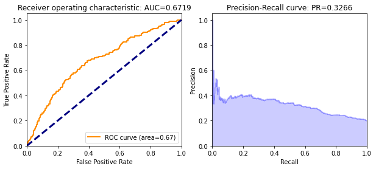

```python
ROC_AUC(glm_test, test_hex, 'loan_default')
```

Our AUC function works well as well, demonstrating an AUC of 0.67 for the sample dataset. This is marginally lower than previous models.

## Creating our initial GLM model with the full-dataset

Now, we use the full train and test data to build a full model using all the features to build our initial model. We use default settings for all parameters, except:

- family = 'Binomial'
- nfolds = 5
- alpha = 0 (Which is ridge regression)
- lambda = 0.001
- Standardize = True
- Remove_collinear_columns = True

```python
target = 'loan_default'
train_hex = h2o.H2OFrame(train)
valid_hex = h2o.H2OFrame(valid)
test_hex = h2o.H2OFrame(test)
```

```
Parse progress: |█████████████████████████████████████████████████████████| 100%
Parse progress: |█████████████████████████████████████████████████████████| 100%
Parse progress: |█████████████████████████████████████████████████████████| 100%
```

```python
glm_model1 = H2OGeneralizedLinearEstimator(
        model_id = 'glm_model1',
        family = 'Binomial',
        nfolds = 5,
        alpha = 0,
        lambda_ = 0.001,
        stopping_metric = 'AUC',
        standardize = True,
        remove_collinear_columns = True,
        seed=257)
glm_model1.train(predictors,target, training_frame=train_hex, validation_frame=valid_hex)
```

```
glm Model Build progress: |███████████████████████████████████████████████| 100%
```

```python
createGains(glm_model1, test_hex, 'loan_default')
```

```
glm prediction progress: |████████████████████████████████████████████████| 100%
```

| decile | count | actual | non_actual | cum_count | cum_actual | cum_non_actual | percent_cum_actual | percent_cum_non_actual | if_random | lift | K_S | gain |
| --- | --- | --- | --- | --- | --- | --- | --- | --- | --- | --- | --- | --- |
| 0 | 1600 | 656 | 944 | 1600 | 656 | 944 | 0.21 | 0.07 | 310.0 | 2.12 | 14.0 | 41.00 |
| 1 | 1600 | 488 | 1112 | 3200 | 1144 | 2056 | 0.37 | 0.16 | 620.0 | 1.85 | 21.0 | 35.75 |
| 2 | 1600 | 434 | 1166 | 4800 | 1578 | 3222 | 0.51 | 0.25 | 930.0 | 1.70 | 26.0 | 32.88 |
| 3 | 1600 | 330 | 1270 | 6400 | 1908 | 4492 | 0.62 | 0.35 | 1240.0 | 1.54 | 27.0 | 29.81 |
| 4 | 1600 | 331 | 1269 | 8000 | 2239 | 5761 | 0.72 | 0.45 | 1550.0 | 1.44 | 27.0 | 27.99 |
| 5 | 1600 | 256 | 1344 | 9600 | 2495 | 7105 | 0.80 | 0.55 | 1860.0 | 1.34 | 25.0 | 25.99 |
| 6 | 1600 | 206 | 1394 | 11200 | 2701 | 8499 | 0.87 | 0.66 | 2170.0 | 1.24 | 21.0 | 24.12 |
| 7 | 1600 | 184 | 1416 | 12800 | 2885 | 9915 | 0.93 | 0.77 | 2480.0 | 1.16 | 16.0 | 22.54 |
| 8 | 1600 | 140 | 1460 | 14400 | 3025 | 11375 | 0.98 | 0.88 | 2790.0 | 1.08 | 10.0 | 21.01 |
| 9 | 1600 | 75 | 1525 | 16000 | 3100 | 12900 | 1.00 | 1.00 | 3100.0 | 1.00 | 0.0 | 19.38 |

Using the full dataset, our model lift has improve to 2.12, with a maximum KS ratio of 27! This points towards the GLM Ratio effectively using alpha and lambda to improve predictions without overfitting. This would mean the model works better with more data.

```
glm prediction progress: |████████████████████████████████████████████████| 100%

   * ROC curve: The ROC curve plots the true positive rate vs. the false rositive sate

	  * The area under the curve (AUC): A value between 0.5 (random) and 1.0 (perfect), measuring the prediction accuracy

   * Recall (R) = The number of true positives / (the number of true positives + the number of false negatives)
```

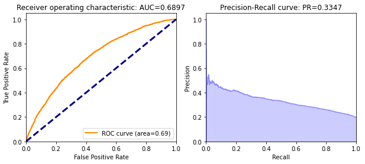

```python
ROC_AUC(glm_model1, test_hex, 'loan_default')
```

The AUC as well has significantly improved to 0.6897 which is close to the 0.69 w obtained with earlier models.

```python
glm_model1._model_json['output']['coefficients_table'].as_data_frame().sort_values(by = 'standardized_coefficients', ascending = False)
#glm_model1.coef_norm()
```

|  | names | coefficients | standardized_coefficients |
| --- | --- | --- | --- |
| 173 | count_abnormal_call_3m | 0.000784 | 0.048367 |
| 66 | mob_brand.sm-w2016 | 0.034180 | 0.034180 |
| 176 | count_abcall_day_2m | 0.000962 | 0.020720 |
| 6 | mob_brand.apple | 0.016846 | 0.016846 |
| 200 | len_service_call_3m | 0.000004 | 0.012061 |
| ... | ... | ... | ... |
| 4 | mob_brand.amoi | -0.259467 | -0.259467 |
| 31 | mob_brand.ipod7 | -0.274848 | -0.274848 |
| 21 | mob_brand.go | -0.284571 | -0.284571 |
| 74 | mob_brand.verizon | -0.289275 | -0.289275 |
| 0 | Intercept | -1.256181 | -1.240194 |

211 rows × 3 columns

A quick look at the coefficients show that ridge regression and removing collinear columns has penalized about 12 columns to have coefficients of zero. However, GLM model uses almost 200 factors and coefficints in the model.

## Using GridSearch for Hyper Parameter Tuning

Since using full predictors seems to have a better effect, lets use all features to tune hyperparameters. We will use h2o package's gridsearch algorithm to run the algorithm through a series of models covering different values for alpha and lambda:

- alpha: 0 - 1, in steps of 0.1 (Leveraging elasticnet)
- lambda: 0.0001, 0.0005, 0.001, 0.005, 0.01, 0.05, 0.1

```python
%%time
%%capture [--no-stderr]

h2o.shutdown()
h2o.init(max_mem_size="5G")

hyper_parameters = {
        'alpha' : [0, 0.1, 0.2, 0.3, 0.4, 0.5, 0.6, 0.7 , 0.8, 0.9, 1],
        'lambda' : [0.0001, 0.0005, 0.001, 0.005, 0.01, 0.05, 0.1]
}
```

```
Wall time: 28.2 s
```

```python
target = 'loan_default'
train_hex = h2o.H2OFrame(train)
valid_hex = h2o.H2OFrame(valid)
test_hex = h2o.H2OFrame(test)
```

```
Parse progress: |█████████████████████████████████████████████████████████| 100%
Parse progress: |█████████████████████████████████████████████████████████| 100%
Parse progress: |█████████████████████████████████████████████████████████| 100%
```

```python
%%time

from h2o.grid.grid_search import H2OGridSearch

glm_params1 = H2OGridSearch(model = H2OGeneralizedLinearEstimator(nfolds = 10, family = 'Binomial', standardize = True, remove_collinear_columns = True),
                            grid_id = 'glm_params1',
                            hyper_params = hyper_parameters)
```

```
Wall time: 0 ns
```

```python
%%time
%%capture [--no-stderr]

glm_params1.train(x = predictors, y = target, training_frame= train_hex)
```

```
Wall time: 8min 48s
```

```python
glm_grid1_perf = glm_params1.get_grid(sort_by='AUC', decreasing=True)
glm_grid1_perf
```

```
       alpha    lambda             model_ids                  auc
0      [0.5]  [1.0E-4]   glm_params1_model_6    0.695714539355043
1      [0.5]  [5.0E-4]  glm_params1_model_17   0.6957072113541125
2      [0.4]  [1.0E-4]   glm_params1_model_5    0.695657109187336
3      [0.1]   [0.001]  glm_params1_model_24   0.6955742246945689
4      [1.0]  [1.0E-4]  glm_params1_model_11   0.6955525620631702
.. ..    ...       ...                   ...                  ...
72     [0.7]     [0.1]  glm_params1_model_74   0.4914379695779819
73     [0.9]     [0.1]  glm_params1_model_76   0.4901169144240523
74     [1.0]     [0.1]  glm_params1_model_77   0.4889087400555105
75     [0.8]     [0.1]  glm_params1_model_75   0.4872388710797272
76     [0.6]     [0.1]  glm_params1_model_73  0.48091469874547854

[77 rows x 5 columns]
```

The grid search algorithm created 77 different models and ranked them by AUC. The best model has an AUC of 0.695 and has the following parameters:

- alpha = 0.5
- lambda = 0.0001

```
glm prediction progress: |████████████████████████████████████████████████| 100%

   * ROC curve: The ROC curve plots the true positive rate vs. the false rositive sate

	  * The area under the curve (AUC): A value between 0.5 (random) and 1.0 (perfect), measuring the prediction accuracy

   * Recall (R) = The number of true positives / (the number of true positives + the number of false negatives)
```

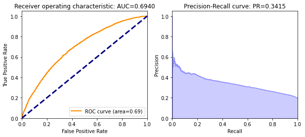

```python
ROC_AUC(glm_grid1_perf.models[0], test_hex, 'loan_default')
```

With these hyperparameter settings, the AUC and precision have both marginally improved!

```python
createGains(glm_grid1_perf.models[0], test_hex, 'loan_default')
```

```
glm prediction progress: |████████████████████████████████████████████████| 100%
```

| decile | count | actual | non_actual | cum_count | cum_actual | cum_non_actual | percent_cum_actual | percent_cum_non_actual | if_random | lift | K_S | gain |
| --- | --- | --- | --- | --- | --- | --- | --- | --- | --- | --- | --- | --- |
| 0 | 1600 | 661 | 939 | 1600 | 661 | 939 | 0.21 | 0.07 | 310.0 | 2.13 | 14.0 | 41.31 |
| 1 | 1600 | 497 | 1103 | 3200 | 1158 | 2042 | 0.37 | 0.16 | 620.0 | 1.87 | 21.0 | 36.19 |
| 2 | 1600 | 426 | 1174 | 4800 | 1584 | 3216 | 0.51 | 0.25 | 930.0 | 1.70 | 26.0 | 33.00 |
| 3 | 1600 | 354 | 1246 | 6400 | 1938 | 4462 | 0.63 | 0.35 | 1240.0 | 1.56 | 28.0 | 30.28 |
| 4 | 1600 | 306 | 1294 | 8000 | 2244 | 5756 | 0.72 | 0.45 | 1550.0 | 1.45 | 27.0 | 28.05 |
| 5 | 1600 | 257 | 1343 | 9600 | 2501 | 7099 | 0.81 | 0.55 | 1860.0 | 1.34 | 26.0 | 26.05 |
| 6 | 1600 | 212 | 1388 | 11200 | 2713 | 8487 | 0.88 | 0.66 | 2170.0 | 1.25 | 22.0 | 24.22 |
| 7 | 1600 | 192 | 1408 | 12800 | 2905 | 9895 | 0.94 | 0.77 | 2480.0 | 1.17 | 17.0 | 22.70 |
| 8 | 1600 | 127 | 1473 | 14400 | 3032 | 11368 | 0.98 | 0.88 | 2790.0 | 1.09 | 10.0 | 21.06 |
| 9 | 1600 | 68 | 1532 | 16000 | 3100 | 12900 | 1.00 | 1.00 | 3100.0 | 1.00 | 0.0 | 19.38 |

While the model has provided similar list to the base model we built, KS has impovied marginally to 28.

## Using AutoML

Now we use the H2O AutoML function to generate a number of different models and compare them. Setting up AutoML is comparatively easier. We specify the following parameters:

- nfolds = 10
- max_runtime = 3600s
- stopping_rounds = 5

```python
target = 'loan_default'
train_hex = h2o.H2OFrame(train)
valid_hex = h2o.H2OFrame(valid)
test_hex = h2o.H2OFrame(test)
```

```
Parse progress: |█████████████████████████████████████████████████████████| 100%
Parse progress: |█████████████████████████████████████████████████████████| 100%
Parse progress: |█████████████████████████████████████████████████████████| 100%
```

```python
from h2o.automl import H2OAutoML

aml_model1 = H2OAutoML(nfolds = 10, max_runtime_secs=3600, stopping_rounds=5)
```

```python
%%time
aml_model1.train(x=predictors, y=target, training_frame=train_hex, leaderboard_frame=valid_hex)
```

```
AutoML progress: |
15:33:08.833: AutoML: XGBoost is not available; skipping it.

████████████████████████████████████████████████████████| 100%
Wall time: 50min 59s
```

```python
aml_model1.leaderboard.head()
```

| model_id | mean_residual_deviance | rmse | mse | mae | rmsle |
| --- | --- | --- | --- | --- | --- |
| StackedEnsemble_AllModels_AutoML_20201123_153308 | 0.142685 | 0.377736 | 0.142685 | 0.286569 | 0.265142 |
| StackedEnsemble_BestOfFamily_AutoML_20201123_153308 | 0.14284 | 0.377942 | 0.14284 | 0.287586 | 0.265562 |
| GBM_grid__1_AutoML_20201123_153308_model_16 | 0.143545 | 0.378874 | 0.143545 | 0.289452 | 0.26552 |
| GBM_grid__1_AutoML_20201123_153308_model_8 | 0.143556 | 0.378887 | 0.143556 | 0.288505 | 0.26563 |
| GBM_grid__1_AutoML_20201123_153308_model_11 | 0.143557 | 0.378889 | 0.143557 | 0.287812 | 0.265854 |
| GBM_grid__1_AutoML_20201123_153308_model_12 | 0.143683 | 0.379056 | 0.143683 | 0.289038 | 0.265777 |
| GBM_grid__1_AutoML_20201123_153308_model_17 | 0.143914 | 0.37936 | 0.143914 | 0.290584 | 0.265799 |
| GBM_grid__1_AutoML_20201123_153308_model_13 | 0.144017 | 0.379496 | 0.144017 | 0.288093 | 0.266207 |
| GBM_1_AutoML_20201123_153308 | 0.144175 | 0.379704 | 0.144175 | 0.288609 | 0.266509 |
| GBM_2_AutoML_20201123_153308 | 0.144224 | 0.379768 | 0.144224 | 0.288005 | 0.266693 |

```python
createGains_aml(aml_model1.leader, test_hex, 'loan_default')
```

```
stackedensemble prediction progress: |████████████████████████████████████| 100%
```

| decile | count | actual | non_actual | cum_count | cum_actual | cum_non_actual | percent_cum_actual | percent_cum_non_actual | if_random | lift | K_S | gain |
| --- | --- | --- | --- | --- | --- | --- | --- | --- | --- | --- | --- | --- |
| 0 | 1600 | 685 | 915 | 1600 | 685 | 915 | 0.22 | 0.07 | 310.0 | 2.21 | 15.0 | 42.81 |
| 1 | 1600 | 535 | 1065 | 3200 | 1220 | 1980 | 0.39 | 0.15 | 620.0 | 1.97 | 24.0 | 38.12 |
| 2 | 1600 | 431 | 1169 | 4800 | 1651 | 3149 | 0.53 | 0.24 | 930.0 | 1.78 | 29.0 | 34.40 |
| 3 | 1600 | 334 | 1266 | 6400 | 1985 | 4415 | 0.64 | 0.34 | 1240.0 | 1.60 | 30.0 | 31.02 |
| 4 | 1600 | 304 | 1296 | 8000 | 2289 | 5711 | 0.74 | 0.44 | 1550.0 | 1.48 | 30.0 | 28.61 |
| 5 | 1600 | 233 | 1367 | 9600 | 2522 | 7078 | 0.81 | 0.55 | 1860.0 | 1.36 | 26.0 | 26.27 |
| 6 | 1600 | 201 | 1399 | 11200 | 2723 | 8477 | 0.88 | 0.66 | 2170.0 | 1.25 | 22.0 | 24.31 |
| 7 | 1600 | 194 | 1406 | 12800 | 2917 | 9883 | 0.94 | 0.77 | 2480.0 | 1.18 | 17.0 | 22.79 |
| 8 | 1600 | 127 | 1473 | 14400 | 3044 | 11356 | 0.98 | 0.88 | 2790.0 | 1.09 | 10.0 | 21.14 |
| 9 | 1600 | 56 | 1544 | 16000 | 3100 | 12900 | 1.00 | 1.00 | 3100.0 | 1.00 | 0.0 | 19.38 |

```
stackedensemble prediction progress: |████████████████████████████████████| 100%

   * ROC curve: The ROC curve plots the true positive rate vs. the false rositive sate

	  * The area under the curve (AUC): A value between 0.5 (random) and 1.0 (perfect), measuring the prediction accuracy

   * Recall (R) = The number of true positives / (the number of true positives + the number of false negatives)
```

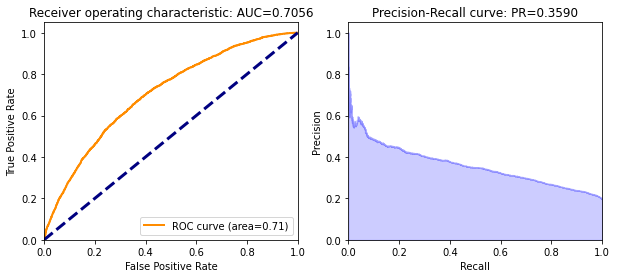

```python
ROC_AUC(aml_model1.leader, test_hex, 'loan_default')
```

Using autoML has improved the lift to 2.21 and KS to 30, this is the best model we have developed so far. A Stacked Ensemble model.

## Using GBM with new features

Since we created new features this week, let us compare running GBM and RFM on the updated dataset for comparison.

```python
from h2o.estimators.gbm import H2OGradientBoostingEstimator

target = 'loan_default'
train_hex = h2o.H2OFrame(train)
test_hex = h2o.H2OFrame(test)
```

```
Parse progress: |█████████████████████████████████████████████████████████| 100%
Parse progress: |█████████████████████████████████████████████████████████| 100%
```

```python
gbm_model4 = H2OGradientBoostingEstimator(
        model_id = 'gbm_model4',
        learn_rate = 0.005,
        ntrees = 5000,
        nfolds=10,
        max_depth = 2,
        min_rows = 100,
        min_split_improvement = 0.0001,
        #balance_classes = True,
        seed=257)
gbm_model4.train(predictors, target, training_frame=train_hex)
```

```
gbm Model Build progress: |███████████████████████████████████████████████| 100%
```

```python
%%time
createGains_aml(gbm_model4, test_hex, 'loan_default')
```

```
gbm prediction progress: |████████████████████████████████████████████████| 100%
Wall time: 7.33 s
```

| decile | count | actual | non_actual | cum_count | cum_actual | cum_non_actual | percent_cum_actual | percent_cum_non_actual | if_random | lift | K_S | gain |
| --- | --- | --- | --- | --- | --- | --- | --- | --- | --- | --- | --- | --- |
| 0 | 1600 | 683 | 917 | 1600 | 683 | 917 | 0.22 | 0.07 | 310.0 | 2.20 | 15.0 | 42.69 |
| 1 | 1600 | 516 | 1084 | 3200 | 1199 | 2001 | 0.39 | 0.16 | 620.0 | 1.93 | 23.0 | 37.47 |
| 2 | 1600 | 415 | 1185 | 4800 | 1614 | 3186 | 0.52 | 0.25 | 930.0 | 1.74 | 27.0 | 33.62 |
| 3 | 1600 | 343 | 1257 | 6400 | 1957 | 4443 | 0.63 | 0.34 | 1240.0 | 1.58 | 29.0 | 30.58 |
| 4 | 1600 | 287 | 1313 | 8000 | 2244 | 5756 | 0.72 | 0.45 | 1550.0 | 1.45 | 27.0 | 28.05 |
| 5 | 1600 | 262 | 1338 | 9600 | 2506 | 7094 | 0.81 | 0.55 | 1860.0 | 1.35 | 26.0 | 26.10 |
| 6 | 1600 | 222 | 1378 | 11200 | 2728 | 8472 | 0.88 | 0.66 | 2170.0 | 1.26 | 22.0 | 24.36 |
| 7 | 1600 | 169 | 1431 | 12800 | 2897 | 9903 | 0.93 | 0.77 | 2480.0 | 1.17 | 16.0 | 22.63 |
| 8 | 1600 | 150 | 1450 | 14400 | 3047 | 11353 | 0.98 | 0.88 | 2790.0 | 1.09 | 10.0 | 21.16 |
| 9 | 1600 | 53 | 1547 | 16000 | 3100 | 12900 | 1.00 | 1.00 | 3100.0 | 1.00 | 0.0 | 19.38 |

## Using RFM with new features

```python
from h2o.estimators.random_forest import H2ORandomForestEstimator

rf_model1 = H2ORandomForestEstimator(
        model_id = 'rf_model1',
        ntrees = 200,
        nfolds=10,
        min_rows=100,
        max_depth = 15,
        mtries = 12,
        min_split_improvement = 0.0001,
        seed=1234)

rf_model1.train(predictors,target,training_frame=train_hex)
```

```
drf Model Build progress: |███████████████████████████████████████████████| 100%
```

```python
%%time
createGains_aml(rf_model1, test_hex, 'loan_default')
```

```
drf prediction progress: |████████████████████████████████████████████████| 100%
Wall time: 976 ms
```

| decile | count | actual | non_actual | cum_count | cum_actual | cum_non_actual | percent_cum_actual | percent_cum_non_actual | if_random | lift | K_S | gain |
| --- | --- | --- | --- | --- | --- | --- | --- | --- | --- | --- | --- | --- |
| 0 | 1600 | 686 | 914 | 1600 | 686 | 914 | 0.22 | 0.07 | 310.0 | 2.21 | 15.0 | 42.88 |
| 1 | 1600 | 478 | 1122 | 3200 | 1164 | 2036 | 0.38 | 0.16 | 620.0 | 1.88 | 22.0 | 36.38 |
| 2 | 1600 | 405 | 1195 | 4800 | 1569 | 3231 | 0.51 | 0.25 | 930.0 | 1.69 | 26.0 | 32.69 |
| 3 | 1600 | 355 | 1245 | 6400 | 1924 | 4476 | 0.62 | 0.35 | 1240.0 | 1.55 | 27.0 | 30.06 |
| 4 | 1600 | 276 | 1324 | 8000 | 2200 | 5800 | 0.71 | 0.45 | 1550.0 | 1.42 | 26.0 | 27.50 |
| 5 | 1600 | 252 | 1348 | 9600 | 2452 | 7148 | 0.79 | 0.55 | 1860.0 | 1.32 | 24.0 | 25.54 |
| 6 | 1600 | 238 | 1362 | 11200 | 2690 | 8510 | 0.87 | 0.66 | 2170.0 | 1.24 | 21.0 | 24.02 |
| 7 | 1600 | 178 | 1422 | 12800 | 2868 | 9932 | 0.93 | 0.77 | 2480.0 | 1.16 | 16.0 | 22.41 |
| 8 | 1600 | 147 | 1453 | 14400 | 3015 | 11385 | 0.97 | 0.88 | 2790.0 | 1.08 | 9.0 | 20.94 |
| 9 | 1600 | 85 | 1515 | 16000 | 3100 | 12900 | 1.00 | 1.00 | 3100.0 | 1.00 | 0.0 | 19.38 |